# Deja Swing: Adaptation Speed and Future Contact Authority

This notebook presents the focused empirical result. A hitter's adaptation rate measures how quickly context-adjusted swing deviation declines as he accumulates same-type looks across pitchers within a game. The central external-validity test asks whether a score estimated in 2025 is associated with 2026 player qualities after controlling for the same quality in 2025.

The main finding is narrow: faster estimated adaptation has a small positive association with later batted-ball authority. The result is exploratory because the outcome family was tested after earlier contact results were inspected. Player rankings retain posterior uncertainty and should not be read as exact talent grades.

```python
from pathlib import Path
import json, sys, tempfile, os
os.environ.setdefault("MPLCONFIGDIR", str(Path(tempfile.gettempdir()) / "deja-swing-matplotlib"))
import numpy as np
import pandas as pd
import matplotlib.pyplot as plt
from IPython.display import display, Image, clear_output

ROOT = next((p for p in [Path.cwd(), *Path.cwd().parents]
             if (p / "config/player_quality_outcomes.json").exists()), None)
if ROOT is None:
    raise FileNotFoundError("Open this notebook inside the mlb-batter-adaptation repository.")
pd.set_option("display.max_columns", 20)
pd.set_option("display.float_format", lambda x: f"{x:,.4f}")
print(f"Project: {ROOT.name} | focused offline replay")
```

```
Project: mlb-batter-adaptation | focused offline replay
```

## Measurement

The expected-swing model estimates the mechanics expected for each pitch context. The realized swing's standardized multivariate distance from that expectation is the deviation outcome. Within each hitter, repeated same-type exposure includes pitches from every pitcher already faced in the game. A positive adaptation score means deviation declines faster as exposure accumulates.

The hierarchy partially pools noisy hitter slopes. Rankings order posterior means, while posterior rate and rank intervals show how uncertain that ordering remains.

|  | season | outcome | tracked_swings | beta_deviation_per_log_dose | ci95_low | ci95_high |
| --- | --- | --- | --- | --- | --- | --- |
| 1 | 2025 | adj_distortion | 249774 | -0.0685 | -0.0798 | -0.0575 |
| 4 | 2025 | adj_absz_attack_angle | 249774 | -0.0330 | -0.0407 | -0.0255 |
| 7 | 2025 | adj_absz_attack_direction | 249774 | -0.0524 | -0.0602 | -0.0443 |
| 10 | 2025 | adj_absz_swing_path_tilt | 249774 | -0.0216 | -0.0298 | -0.0130 |
| 13 | 2025 | adj_absz_bat_speed | 249774 | -0.0364 | -0.0466 | -0.0271 |
| 16 | 2025 | adj_absz_swing_length | 249774 | -0.0377 | -0.0463 | -0.0293 |
| 19 | 2026 | adj_distortion | 238111 | -0.0590 | -0.0712 | -0.0466 |
| 22 | 2026 | adj_absz_attack_angle | 238111 | -0.0330 | -0.0417 | -0.0243 |
| 25 | 2026 | adj_absz_attack_direction | 238111 | -0.0403 | -0.0487 | -0.0319 |
| 28 | 2026 | adj_absz_swing_path_tilt | 238111 | -0.0315 | -0.0412 | -0.0220 |
| 31 | 2026 | adj_absz_bat_speed | 238111 | -0.0245 | -0.0350 | -0.0140 |
| 34 | 2026 | adj_absz_swing_length | 238111 | -0.0213 | -0.0310 | -0.0123 |

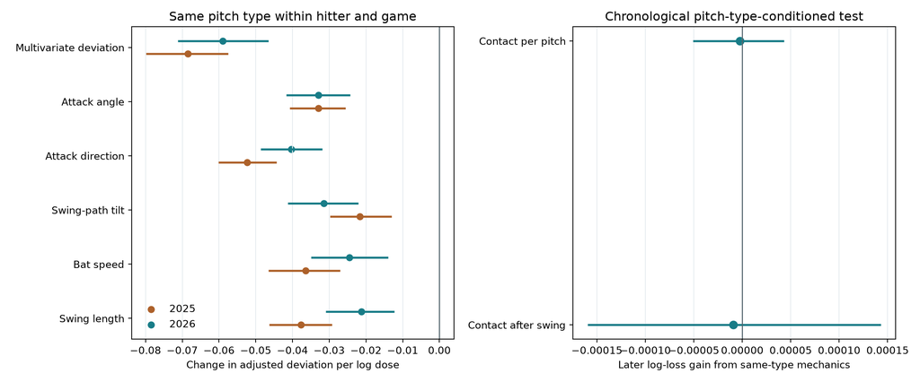

```python
population = pd.read_csv(ROOT / "results/abstract_claim_audit/population_changes.csv")
display(population.loc[population.model.eq("type_fe_plus_general_exposure"),
    ["season", "outcome", "tracked_swings", "beta_deviation_per_log_dose",
     "ci95_low", "ci95_high"]])
display(Image(filename=str(ROOT / "results/abstract_claim_audit/claim_audit.png")))
```

The population association appears in both observed seasons and remains after accounting for repetition against the same pitcher. This establishes a repeated-exposure pattern in swing mechanics at the population level. It does not by itself identify a causal learning effect.

## Future player qualities

The validation cohort contains 261 hitters with at least 200 plate appearances and common opportunity thresholds in both periods. Twelve future qualities cover swing decisions, bat-to-ball skill, discipline, contact authority, overall production, and bat speed. Each analysis controls for the player's 2025 value of the same quality.

The five-component authority composite averages standardized hard-hit rate, barrel rate, mean exit velocity, 90th-percentile exit velocity, and expected wOBA on contact. It was defined as a contact-authority domain, without choosing the subset that produced the largest observed correlation.

|  | outcome | label | n_players | partial_rank_rho | ci95_low | ci95_high | permutation_p | standardized_ols_beta | standardized_huber_beta | quantile_beta_25 | quantile_beta_50 | quantile_beta_75 | cv_mse_gain_pct |
| --- | --- | --- | --- | --- | --- | --- | --- | --- | --- | --- | --- | --- | --- |
| 0 | authority_composite | Batted-ball authority composite | 261 | 0.1307 | 0.0087 | 0.2485 | 0.0354 | 0.0694 | 0.0400 | 0.0567 | 0.0091 | 0.0516 | 0.5350 |
| 1 | discipline_composite | Plate-discipline composite | 261 | -0.0158 | -0.1351 | 0.0974 | 0.8010 | -0.0030 | -0.0089 | 0.0089 | -0.0470 | 0.0505 | -0.7975 |

|  | label | partial_rank_rho | partial_rank_ci95_low | partial_rank_ci95_high | partial_rank_p | bh_q | maxT_p | standardized_huber_beta | cv_mse_gain_pct |
| --- | --- | --- | --- | --- | --- | --- | --- | --- | --- |
| 0 | Chase rate | -0.0126 | -0.1314 | 0.1096 | 0.8389 | 0.9278 | 1.0000 | 0.0031 | -0.6002 |
| 1 | Zone swing rate | 0.0210 | -0.1117 | 0.1463 | 0.7357 | 0.9278 | 1.0000 | 0.0060 | -0.9556 |
| 2 | Whiff rate | 0.0140 | -0.1033 | 0.1330 | 0.8222 | 0.9278 | 1.0000 | 0.0101 | -0.8347 |
| 3 | Strikeout rate | 0.0056 | -0.1102 | 0.1218 | 0.9278 | 0.9278 | 1.0000 | 0.0016 | -0.9185 |
| 4 | Walk rate | -0.0094 | -0.1252 | 0.1029 | 0.8793 | 0.9278 | 1.0000 | 0.0065 | -0.6542 |
| 5 | Hard-hit rate | 0.1300 | 0.0051 | 0.2450 | 0.0359 | 0.1435 | 0.2917 | 0.0741 | 0.5022 |
| 6 | Barrel rate | 0.0875 | -0.0254 | 0.2127 | 0.1589 | 0.3498 | 0.7816 | 0.0404 | 0.0712 |
| 7 | Mean exit velocity | 0.1387 | 0.0200 | 0.2526 | 0.0251 | 0.1435 | 0.2132 | 0.0542 | 0.3319 |
| 8 | 90th-percentile exit velocity | 0.0842 | -0.0284 | 0.1967 | 0.1749 | 0.3498 | 0.8138 | 0.0372 | 0.0711 |
| 9 | Expected wOBA on contact | 0.1024 | -0.0136 | 0.2277 | 0.0989 | 0.2968 | 0.5991 | 0.0665 | -0.0578 |
| 10 | wOBA | -0.0077 | -0.1311 | 0.1098 | 0.9014 | 0.9278 | 1.0000 | 0.0075 | -0.8187 |
| 11 | Mean bat speed | 0.1491 | 0.0283 | 0.2596 | 0.0160 | 0.1435 | 0.1430 | 0.0284 | 0.4970 |

|  | comparison | n_players | partial_rank_rho | ci95_low | ci95_high |
| --- | --- | --- | --- | --- | --- |
| 0 | 2025 annual score to 2026 through September 20 | 261 | 0.1307 | 0.0156 | 0.2416 |
| 1 | 2025 annual score to 2026 second half | 160 | 0.0652 | -0.0887 | 0.2131 |
| 2 | 2025 first-half score to 2025 second half | 189 | -0.0553 | -0.1906 | 0.0817 |
| 3 | 2026 first-half score to 2026 second half | 172 | 0.0754 | -0.0684 | 0.2263 |

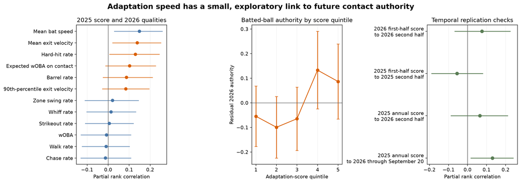

```python
outcomes = pd.read_csv(ROOT / "results/player_quality_outcomes/outcome_associations.csv")
composites = pd.read_csv(ROOT / "results/player_quality_outcomes/composite_associations.csv")
temporal = pd.read_csv(ROOT / "results/player_quality_outcomes/temporal_checks.csv")
display(composites)
display(outcomes[["label", "partial_rank_rho", "partial_rank_ci95_low",
    "partial_rank_ci95_high", "partial_rank_p", "bh_q", "maxT_p",
    "standardized_huber_beta", "cv_mse_gain_pct"]])
display(temporal)
display(Image(filename=str(ROOT / "results/player_quality_outcomes/quality_outcomes.png")))
```

The authority composite partial rank correlation is 0.131, with a 95% bootstrap interval from 0.009 to 0.249 and a permutation p-value of 0.035. OLS, Huber regression, and quantile regression point in the same general direction. Adding the score improves repeated cross-validation mean squared error by 0.53%.

## Player rankings and curves

|  | point_rank | player_name | posterior_mean | cri90_low | cri90_high | rank_cri90_low | rank_cri90_high | prob_positive | n_exposures |
| --- | --- | --- | --- | --- | --- | --- | --- | --- | --- |
| 0 | 1 | Brett Baty | 0.0694 | 0.0227 | 0.1224 | 2.0000 | 316.0000 | 0.9932 | 794 |
| 1 | 2 | Isiah Kiner-Falefa | 0.0691 | 0.0211 | 0.1219 | 2.0000 | 328.0000 | 0.9910 | 761 |
| 2 | 3 | Shea Langeliers | 0.0684 | 0.0234 | 0.1178 | 3.0000 | 309.0000 | 0.9956 | 988 |
| 3 | 4 | Trevor Larnach | 0.0640 | 0.0158 | 0.1182 | 3.0000 | 377.0500 | 0.9858 | 955 |
| 4 | 5 | Adolis García | 0.0623 | 0.0164 | 0.1124 | 4.0000 | 365.0500 | 0.9876 | 1108 |
| 5 | 6 | Jose Altuve | 0.0604 | 0.0143 | 0.1110 | 5.0000 | 376.0500 | 0.9860 | 1070 |
| 6 | 7 | Luke Raley | 0.0558 | 0.0093 | 0.1094 | 5.0000 | 420.0500 | 0.9762 | 438 |
| 7 | 8 | Tristan Gray | 0.0552 | 0.0048 | 0.1110 | 4.9500 | 445.0000 | 0.9624 | 158 |
| 8 | 9 | Brooks Lee | 0.0542 | 0.0074 | 0.1067 | 5.9500 | 430.0500 | 0.9702 | 949 |
| 9 | 10 | Nick Castellanos | 0.0534 | 0.0106 | 0.1028 | 8.0000 | 402.0500 | 0.9774 | 1242 |
| 10 | 11 | Spencer Torkelson | 0.0532 | 0.0084 | 0.1028 | 7.9500 | 422.0500 | 0.9728 | 1153 |
| 11 | 12 | Javier Báez | 0.0530 | 0.0074 | 0.1022 | 7.0000 | 425.0500 | 0.9702 | 822 |
| 12 | 13 | Jake Cronenworth | 0.0509 | 0.0042 | 0.1035 | 7.0000 | 444.0000 | 0.9664 | 893 |
| 13 | 14 | Riley Greene | 0.0496 | -0.0004 | 0.1043 | 6.0000 | 467.0000 | 0.9486 | 1384 |
| 14 | 15 | Yainer Diaz | 0.0496 | 0.0088 | 0.0955 | 12.0000 | 423.0000 | 0.9768 | 1086 |
| 15 | 16 | Byron Buxton | 0.0480 | 0.0016 | 0.0988 | 10.0000 | 464.0000 | 0.9546 | 1031 |
| 16 | 17 | Austin Riley | 0.0476 | -0.0002 | 0.1004 | 8.0000 | 469.0000 | 0.9488 | 890 |
| 17 | 18 | Sal Stewart | 0.0459 | -0.0044 | 0.1011 | 9.0000 | 486.0000 | 0.9342 | 106 |
| 18 | 19 | Nick Fortes | 0.0457 | -0.0037 | 0.0995 | 9.0000 | 489.0000 | 0.9342 | 413 |
| 19 | 20 | Andrew Vaughn | 0.0454 | 0.0001 | 0.0928 | 12.0000 | 474.0000 | 0.9502 | 799 |
| 20 | 21 | Alec Burleson | 0.0452 | 0.0001 | 0.0938 | 13.9500 | 465.0000 | 0.9504 | 935 |
| 21 | 22 | Tim Anderson | 0.0452 | -0.0040 | 0.1014 | 8.0000 | 486.0000 | 0.9298 | 183 |
| 22 | 23 | Oscar Gonzalez | 0.0452 | -0.0052 | 0.1012 | 8.0000 | 494.0000 | 0.9300 | 141 |
| 23 | 24 | LaMonte Wade Jr. | 0.0450 | -0.0044 | 0.0994 | 9.0000 | 495.0500 | 0.9324 | 412 |
| 24 | 25 | Jonathan India | 0.0444 | -0.0056 | 0.0972 | 10.0000 | 490.0500 | 0.9316 | 920 |

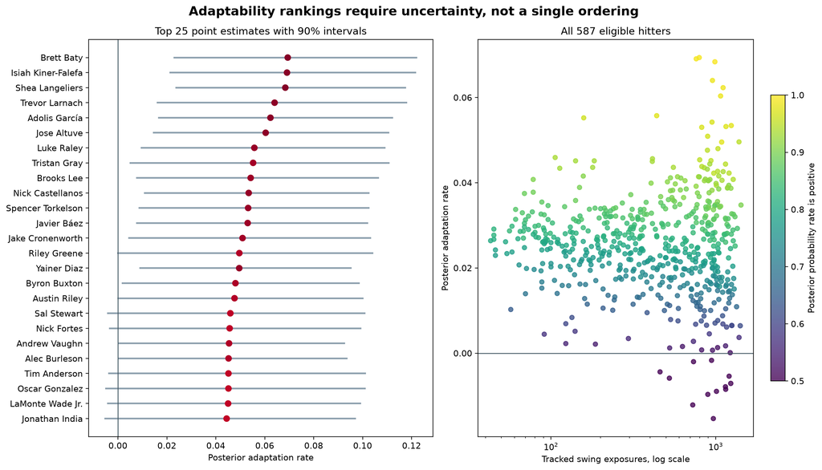

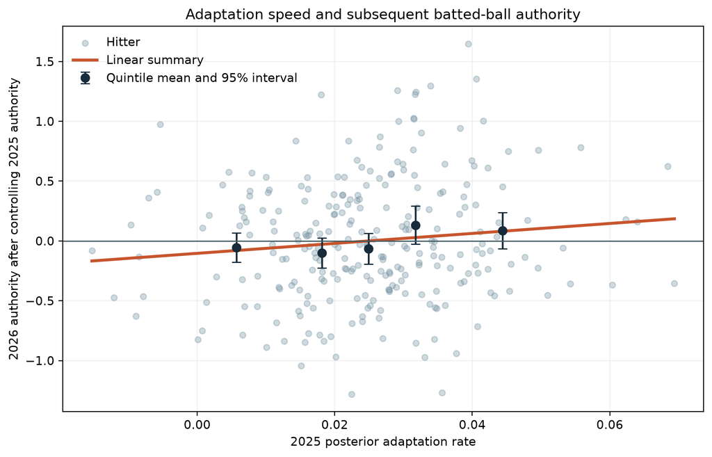

```python
rankings = pd.read_csv(ROOT / "results/adaptability_rankings/player_rankings.csv")
curves = pd.read_csv(ROOT / "results/cross_pitcher/player_curves.csv")
curves = curves.loc[curves.model.eq("pooled_geometry")]
display(rankings.loc[rankings.season.eq(2025),
    ["point_rank", "player_name", "posterior_mean", "cri90_low", "cri90_high",
     "rank_cri90_low", "rank_cri90_high", "prob_positive", "n_exposures"]].head(25))
display(Image(filename=str(ROOT / "results/adaptability_rankings/adaptability_rankings.png")))
display(Image(filename=str(ROOT / "results/adaptability_rankings/adaptability_authority.png")))
```

```python
try:
    import ipywidgets as widgets
    eligible = rankings.loc[rankings.season.eq(2025)].sort_values("player_name")
    hitter = widgets.Dropdown(
        options=[(r.player_name, int(r.player_id)) for r in eligible.itertuples()],
        description="Hitter:", layout=widgets.Layout(width="360px"))
    season = widgets.ToggleButtons(options=[2025, 2026], description="Season:")
    output = widgets.Output()

    def show_player(*_):
        with output:
            clear_output(wait=True)
            row = rankings.loc[rankings.player_id.eq(hitter.value) &
                                rankings.season.eq(season.value)]
            if row.empty:
                print("This hitter did not meet the estimation rules in that season.")
                return
            row = row.iloc[0]
            curve = curves.loc[curves.player_id.eq(hitter.value) &
                               curves.season.eq(season.value)].sort_values("prior_same_type_pitches")
            display(row[["player_name", "point_rank", "posterior_mean", "cri90_low",
                "cri90_high", "rank_median", "rank_cri90_low", "rank_cri90_high",
                "prob_positive", "n_exposures", "future_authority_residual"]].to_frame("value"))
            fig, ax = plt.subplots(figsize=(8, 4.2))
            ax.plot(curve.prior_same_type_pitches, curve.change_median,
                    color="#19757b", lw=2.5)
            ax.fill_between(curve.prior_same_type_pitches, curve.change_ci90_low,
                            curve.change_ci90_high, color="#19757b", alpha=.18)
            ax.axhline(0, color="#52636b", lw=1)
            ax.set(xlabel="Earlier same-type pitches in game",
                   ylabel="Change in swing deviation",
                   title=f"{row.player_name}: {season.value} fitted adaptation curve")
            ax.grid(alpha=.18)
            display(fig)
            plt.close(fig)

    hitter.observe(show_player, names="value")
    season.observe(show_player, names="value")
    display(widgets.VBox([widgets.HBox([hitter, season]), output]))
    show_player()
except ImportError:
    print("Install ipywidgets for the notebook selector. The standalone explorer remains available.")
```

## Interpretation

The evidence supports a candidate mechanical interpretation: hitters whose swings converge toward their context-specific expectation more quickly also tend to maintain or develop stronger contact authority in the next observed season. The association is small and is not a broad measure of offensive quality.

A new untouched season is required to establish persistence. Until then, the rankings are estimates for research and scouting follow-up, not definitive player grades.

## Reproduction

Run `make submission` from the repository root to regenerate the claim audit, player-quality analysis, rankings, notebook, and tests. The full exploratory record remains in the repository so the focused result can be audited against null and failed specifications.